# Regression Analysis Coursework

Jonathan Bourne

Saturday, October 25, 2014

# Exectutive Summary

Source code is available on gitHub[https://github.com/JonnoB/Data-Science-Regression]

# Introduction

You work for Motor Trend, a magazine about the automobile industry. Looking at a data set of a collection of cars, they are interested in exploring the relationship between a set of variables and miles per gallon (MPG) (outcome). They are particularly interested in the following two questions:

“Is an automatic or manual transmission better for MPG” “Quantify the MPG difference between automatic and manual transmissions”

# Data gathering and exploration

The data set comes from R datasets it includes 32 observations and 11 variables. No observations were removed from the data set. The follwing variables were converted from numeric to factor variables am, vs, cyl, gear, carb, no transformations were performed on the data set no new variables were created. A plot showing the relationship between all variables can be found in the appendix

|  | Type | V2 |
| --- | --- | --- |
| 1 | All Cars | 0.1229 |
| 2 | Manual | 0.5363 |
| 3 | Automatic | 0.8987 |

The above table shows that the results of the Shapiro Wilks test which suggest that the distribution of the mpg is reasonably normal.

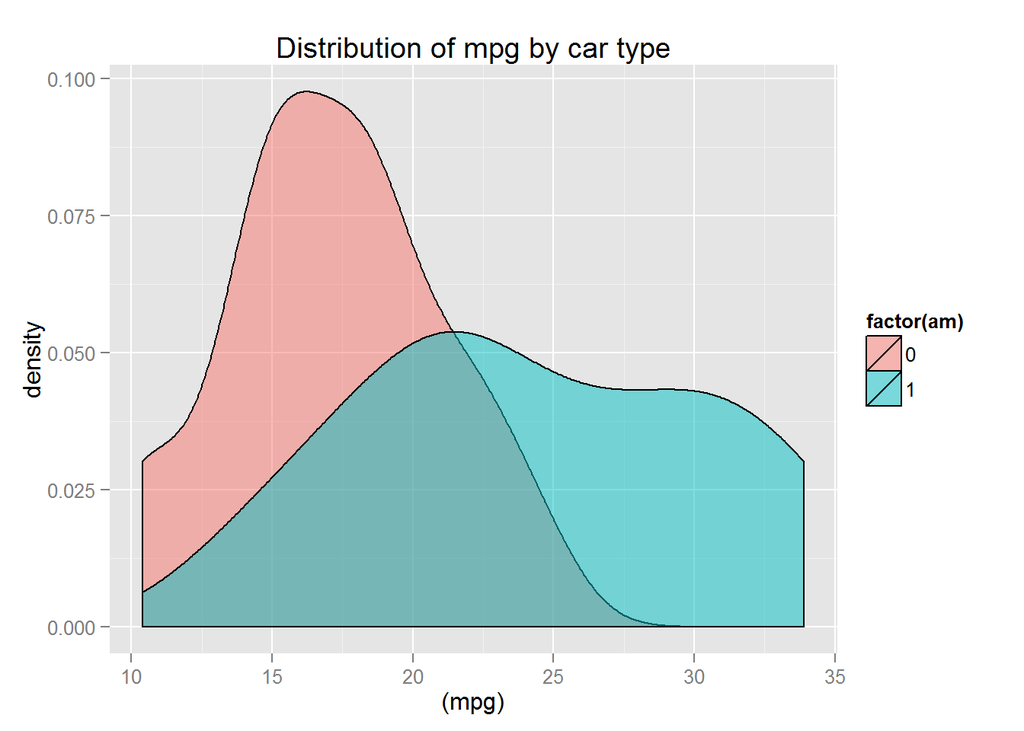